# Decoding Music-Evoked Emotions in the Auditory and Motor Cortex | Cerebral Cortex | Oxford Academic

[figure not shown]

[figure not shown]

[figure not shown]

Journal Article

# Decoding Music-Evoked Emotions in the Auditory and Motor Cortex

Vesa Putkinen, Sanaz Nazari-Farsani, Kerttu Seppälä, Tomi Karjalainen, Lihua Sun, Henry K Karlsson, Matthew Hudson, Timo T Heikkilä, Jussi Hirvonen, Lauri Nummenmaa

*Cerebral Cortex*, Volume 31, Issue 5, May 2021, Pages 2549–2560, https://doi.org/10.1093/cercor/bhaa373

Published:

24 December 2020

Article history

## Abstract

Music can induce strong subjective experience of emotions, but it is debated whether these responses engage the same neural circuits as emotions elicited by biologically significant events. We examined the functional neural basis of music-induced emotions in a large sample (*n* = 102) of subjects who listened to emotionally engaging (happy, sad, fearful, and tender) pieces of instrumental music while their hemodynamic brain activity was measured with functional magnetic resonance imaging (fMRI). Ratings of the four categorical emotions and liking were used to predict hemodynamic responses in general linear model (GLM) analysis of the fMRI data. Multivariate pattern analysis (MVPA) was used to reveal discrete neural signatures of the four categories of music-induced emotions. To map neural circuits governing non-musical emotions, the subjects were scanned while viewing short emotionally evocative film clips. The GLM revealed that most emotions were associated with activity in the auditory, somatosensory, and motor cortices, cingulate gyrus, insula, and precuneus. Fear and liking also engaged the amygdala. In contrast, the film clips strongly activated limbic and cortical regions implicated in emotional processing. MVPA revealed that activity in the auditory cortex and primary motor cortices reliably discriminated the emotion categories. Our results indicate that different music-induced basic emotions have distinct representations in regions supporting auditory processing, motor control, and interoception but do not strongly rely on limbic and medial prefrontal regions critical for emotions with survival value.

emotion, fMRI, music, MVPA, pattern classification

Issue Section:

[Original Article](https://academic.oup.com/cercor/search-results?f_TocHeadingTitle=Original+Article)

## Introduction

Human attraction to music stems from the aesthetic experience and strong emotional reactions music evokes. Basic emotion theories posit a finite number of innate and universal emotions that have evolved because they promote survival by motivating adaptive behaviors and help maintaining physiological homeostasis (Ekman 1992), and numerous neuroimaging studies have tested whether music is capable of activating the survival circuits underlying these emotions (Mitterschiffthaler et al. 2007; Brattico et al. 2011; Koelsch et al. 2013). Indeed, emotional responses to music show many hallmarks of basic emotions including distinct subjective experience, emotional expression, action tendencies, changes in the autonomic nervous system activation (Juslin and Vastfjall 2008) and distinct effects of thought and judgment (Vuoskoski and Eerola 2012). Yet, it seems counterintuitive that that instrumental music could elicit “genuine” basic emotions because emotional reactions to music do not have unambiguous causes (real-life threat, success, or loss, etc.) and they do not involve events that have obvious goal or survival-relevant consequences (Konečni 2008; Scherer and Zentner 2008). Thus, even though listeners often interpret their subjective reactions to music as basic emotions, these responses may differ from genuine basic emotions in the underlying neural processes.

Some acoustic features contributing to different music-induced emotions may be universally recognizable (Fritz et al. 2009), perhaps because similar cues communicate emotion in human vocalizations and music (Juslin and Laukka 2003; Frühholz et al. 2016). These features may recruit partly the same neural networks across the domains (Peretz 2010; Escoffier et al. 2013). Music-induced emotions are nevertheless dependent on cultural learning (Higgins 2012; McDermott et al. 2016) and therefore may engage partly distinct neural systems than the putatively innate basic emotions*.*

Emotions elicited by biologically salient stimuli consistently engage subcortical structures such as the amygdala, thalamus, striatum, and brain stem and cortical regions such as the anterior cingulate, insula, and medial and orbital frontal cortices (Kober et al. 2008; De La Vega et al. 2016). A recent meta-analysis indicates that different music-induced emotions also activate these structures suggesting that these emotions may rely on some of the same evolutionarily adaptive mechanisms that underlie emotions with survival value (Koelsch 2014). However, it is unclear whether the activation of these circuits discriminates between specific categories of music-induced emotions. Thus far, fMRI studies have largely failed to find reliable category-specific correlates of music-induced emotions and often contradict each other in terms of the regions they implicate in specific music-induced emotions such as happiness (Mitterschiffthaler et al. 2007; Brattico et al. 2011), sadness (Mitterschiffthaler et al. 2007; Trost et al. 2012), or fear (Koelsch et al. 2013; Bogert et al. 2016).

The mass univariate general linear model (GLM) has been the dominating analysis approach in fMRI studies on emotions. More recently, multivariate pattern analysis (MVPA) has been adopted in order to decode high-dimensional regularities in fMRI data that predict different basic and social emotions (Nummenmaa and Saarimäki 2017). These studies indicate that discrete emotions perceived in facial expressions, bodily movements, and vocalizations (Ethofer et al. 2009; Peelen et al. 2010; Volynets et al. 2020) can be decoded from brain activity in sensory cortices while emotional states induced by stories, movies, and imagery are represented in discrete and widely distributed activity patterns across various cortical and subcortical regions (Sitaram et al. 2011; Kassam et al. 2013; Saarimäki et al. 2015). Thus, different music-evoked emotions might also be based on distinct but spatially overlapping neural activation patterns not captured by univariate analysis. Two prior MVPA-fMRI studies indicate that activity patterns in the auditory cortices predict whether subjects heard short bursts of violin and clarinet sounds conveying either sadness, happiness, or fear (Paquette et al. 2018; Sachs et al. 2018). These activity patterns probably reflect sensory processing of acoustic properties with different emotional connotations, but it is unclear whether such auditory cortical patterns predict different emotions actually felt by the listeners during naturalistic music-listening. A few other emotion-related MVPA-fMRI studies have used music as stimuli but either collapsed data obtained with music and other means of emotion-induction precluding inferences specifically about music-induced emotions (Kragel and LaBar 2015) or focused only on emotional valence instead of discrete music-induced emotions (Kim et al. 2017). Thus, it remains unclear whether distinct music-induced emotions are represented in anatomically distributed activity patterns similarly to emotions elicited by non-musical stimuli.

### The Current Study

Here we combined GLM and multivariate pattern analyses of fMRI data from a large sample of 102 subjects to test whether 1) different music-induced emotions reliably activate brain’s emotion circuit similarly as emotions elicited by biologically salient episodes shown in videos and 2) whether music-evoked emotional responses are organized in a discrete fashion in the brain. We focused on emotions happiness, sadness, fear, and tenderness because they cover the four quadrants of the valence–arousal–circumplex, are included in categorical models frequently used to describe music-induced emotions in the literature (Zentner et al. 2008; Eerola and Vuoskoski 2010), and are rated consistently across listeners (Juslin 2013). Subjects underwent fMRI while they listened to excerpts of instrumental movie soundtracks validated previously to reliably elicit these emotions. To map neural circuits governing non-musical emotions, we also scanned the same subjects in a previously validated emotion “localizer” paradigm (Lahnakoski et al. 2012; Karjalainen et al. 2017; Karjalainen et al. 2019) in which subjects view film clips with positive and negative emotional content. Like music, fictitious films are devoid of real-life consequences and yet elicit strong emotions. However, unlike instrumental music, movies offer a rich, multimodal simulation of the real-life emotional events. Thereby, movies provide a naturalistic paradigm for mapping neural circuits supporting emotions in real-world situations (Sonkusare et al. 2019). We found that music-induced basic emotions engaged regions supporting auditory processing, motor control, somatosensation, and interoception but did not strongly activate limbic and medial prefrontal regions that govern non-musical emotions. Furthermore, MVPA revealed that activity in the auditory and primary motor cortices, but not in the core emotion circuits, reliably discriminated the emotion categories.

## Materials and Methods

### Subjects

Altogether 102 volunteers participated in the study (51 females, mean age 31 years, range 20–57 years). Fifty percent of subjects had received no formal training on a musical instrument (The median for the months of training was 6.3.) The exclusion criteria included a history of neurological or psychiatric disorders, alcohol or substance abuse, current use of medication affecting the central nervous system, and the standard MRI exclusion criteria. Two additional subjects were scanned but excluded from further analyses because unusable MRI data due to gradient coil malfunction. All subjects gave an informed, written consent and were compensated for their participation. The ethics board of the Hospital District of Southwest Finland had approved the protocol, and the study was conducted in accordance with the Declaration of Helsinki.

### Study Design

The stimuli were 18 45-s (including a 10-ms fadeout) excerpts of instrumental music. Sixteen excerpts were chosen from a set of movie soundtracks based on high ratings for happiness, sadness, fear, or tenderness in a previous study (Eerola and Vuoskoski 2010). For each of the four emotions, four stimuli were selected that had received high rating for the target emotion and low ratings for the other three (see the Supplementary Material for details). Two additional excerpts of instrumental rock (Far Beyond the Sun by Yngwie J. Malmsteen) were included to add variation in the musical material in terms of genre and instrumentation. Instrumental music was used to minimize the contribution of semantic knowledge on the emotional responses.

A 45-s random tone sequence followed by 45 s of silence was presented at the beginning of the run. After this, the musical excerpts were presented in a fixed pseudo-random order without silent breaks in between. The last excerpt was followed by 45 s of silence, another 45-s random tone sequence, and a third 45-s silent period (see the Supplementary Material for the contrasts between music vs. control stimuli and music vs. silence). Subjects were asked to remain still during the fMRI and focus on the feelings evoked by the music. Stimuli were presented binaurally via MRI-compatible headphones (Sensimetrics S14) at a comfortable level adjusted individually for each participant. After the scanning session, the subjects listened to each music excerpt again and rated for experience of fear, happiness, sadness, tenderness, and liking on a scale ranging from 1 to 10 (1 = extremely weak, 10 = extremely strong). Ratings were done using an online rating tool developed in-house (https://gitlab.utu.fi/tithei/pet-rating, Heikkilä et al. 2020). Complete ratings were obtained from 91 participants. Ratings averaged across these subjects were used as regressors in the analysis of the BOLD data (cf. Trost et al. 2012).

To map brain regions governing non-musical emotions, we used a previously validated emotion “localizer” paradigm in which the subjects viewed a compilation of 96 movie clips extracted from mainstream English language feature films (mean duration 12.5 s; total duration 20 min) containing variable emotional and non-emotional content (for details, see Karjalainen et al. 2017, 2019; Lahnakoski et al. 2012). The movie clips were presented in fixed order without breaks in between. The film clips contained scenes with displays of positive emotions (e.g., laughter, friendly discussion, expression of affection between parents and children or between romantic partners), negative emotions (e.g., crying, arguing, violence), scenes without emotional content (e.g., humans in a neutral emotional state, objects, landscapes). Dynamic ratings with a 4-s temporal resolution were obtained for the intensity of positive and negative emotions observed in the film clips from a separate sample of subjects (*n* = 6) who did not participate in the fMRI study. The average ratings were subsequently used as regressors in GLM analysis. The film clips were presented via NordicNeuroLab VisualSystem binocular display (audio was delivered as described above).

### MRI Data Acquisition

The MRI data were acquired using a Phillips Ingenuity TF PET/MR 3-T whole-body scanner. High-resolution (1 mm<sup>3</sup>) structural images were obtained with a T1-weighted sequence (TR 9.8 ms, TE 4.6 ms, flip angle 7°, 250 mm FOV, 256 × 256 reconstruction matrix). A total of 407 and 470 functional volumes were acquired for the music and movie experiments, respectively, with a T2*-weighted echo-planar imaging sequence (TR 2600 ms, TE 30 ms, 75° flip angle, 240 mm FOV, 80 × 80 reconstruction matrix, 62.5 kHz bandwidth, 3.0 mm slice thickness, 45 interleaved slices acquired in ascending order without gaps).

### Structural and Functional MRI Data Preprocessing

MRI data were preprocessed using fMRIPprep 1.3.0.2 (Esteban et al. 2019). The following preprocessing was performed on the anatomical T1-weighted (T1w) reference image: correction for intensity non-uniformity, skull-stripping, brain surface reconstruction, and spatial normalization to the ICBM 152 Nonlinear Asymmetrical template version 2009c (Fonov et al. 2009) using nonlinear registration with antsRegistration (ANTs 2.2.0) and brain tissue segmentation. The following preprocessing was performed on the functional data: co-registration to the T1w reference, slice-time correction, spatial smoothing with a 6-mm Gaussian kernel, automatic removal of motion artifacts using ICA-AROMA (Pruim et al. 2015), and resampling of the MNI152NLin2009cAsym standard space. Low-frequency drifts were removed with a 240-s-Savitzky–Golay filter (Çukur et al. 2013).

### Full-Volume GLM Data Analysis

The fMRI data analyzed in SPM12 (Wellcome Trust Center for Imaging, London, UK, http://www.fil.ion.ucl.ac.uk/spm). To reveal regions activated by music vs. silence, a general linear model (GLM) was fitted to the data where the music sequence and the silent periods were modeled with separate boxcar regressors. The regional effects of the five emotion dimensions were assessed with a GLM where the design matrix included the music boxcar regressor and each of the emotion rating regressors as parametric modulators. For the movie experiment, the average dynamic rating for the intensity of positive and negative emotions was used as a regressor in the GLM analysis. Contrast images for the main effects of music, silence, and each emotion regressor were generated for each participant and subjected to a second-level analysis. Clusters surviving family-wise error (FWE) correction (*P* < 0.05) are reported.

### Region-of-Interest Analyses

Beta weights for each of the five emotion regressors were extracted from 15 anatomical regions of interest (ROI) implicated in emotional processing (Paquette et al. 2018; Saarimäki et al. 2015, 2018). These included the amygdala, caudate, putamen, pallidum, thalamus, hippocampus, insula, anterior and posterior cingulate, SMA, precentral and postcentral gyri, precuneus, frontal pole, and auditory cortex. The mean beta weights for each ROI were calculated from the first-level contrast images of each subject using ROI masks derived from the AAL atlas. The beta weights for each emotion in each ROI were compared against zero with separate one-sample *t* tests.

### Multivariate Pattern Analysis

A between-subject classification of the four emotion categories (fear, happiness, sadness, and tenderness) was performed in Python using the PyMVPA toolbox (Hanke et al. 2009). A support vector machine with radial basis function (RBF) kernel was trained to recognize the emotion categories using leave-one-subject-out cross-validation, where the classifier is trained on the data from all except one subject and tested on the hold-out subject data; this procedure is repeated N times so that each subject is used once as the hold-out subject; this kind of leave-one-subject-out cross-validation tests the generalizability of the results across the sample of the subjects. A subject-wise GLM with regressors for each stimulus was fit to the data resulting in 16 beta weights (4 emotion categories × 4 song per category) per voxel for each subject, and the MVPA was applied to the beta images. The beta weights were normalized to have zero mean and unit variance before application of MVPA. This analysis was performed using whole-brain data (with non-brain voxel masked out) and within a subset of the ROIs (amygdala, hippocampus, thalamus, anterior and posterior cingulate, SMA, precentral and postcentral gyri, precuneus, frontal pole, auditory cortex) where emotion classification has been successful in previous studies (Paquette et al. 2018; Saarimäki et al. 2015). In the whole-brain MVPA, an ANOVA feature selection was applied to the training set within each cross-validation where 5000 voxels with the highest *F* score were selected. Classification accuracy was quantified by computing the proportion of correctly classified songs relative to the number of songs in each of the four categories (i.e., recall). To estimate the null distribution for the classification accuracies (naïve chance level 25%), the following procedure was repeated 500 times: we 1) randomly shuffled emotion category labels; 2) ran the whole-brain MVPA with 102 leave-one-subject-out cross-validations, where the classifier was trained on the data with shuffled labels from N-1 subject and tested on data with correct labels from the remaining subject; and 3) calculated the classification accuracies on each of the 500 iterations. If the true accuracy was larger than 95% of the accuracies obtained with the randomly shuffled labels, the true accuracy was considered significant with an alpha of 0.05.

**Figure 1**

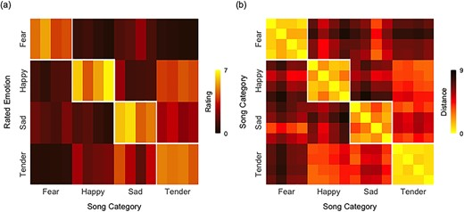

(*a*) Mean ratings for the intensity of each emotion for each musical excerpt. (*b*) Rating dissimilarity matrix (Euclidean distance) for each song pair.